# PetFood_Case

```python
import pandas as pd
import numpy as np
import matplotlib.pyplot as plt
import datetime
import matplotlib.dates as mdates
import matplotlib.patches as mpatches
import scipy
from scipy import stats
%matplotlib inline
```

```python
xls = pd.ExcelFile('20180509_Business_Analyst_Case.xlsx')
df = pd.read_excel(xls, 'Data')
```

```python
#create dataframe from csv
df = df.drop(np.arange(7)).reset_index()
df.columns = df.iloc[0]
df = df[1:]
df = df.reset_index().drop(columns = [7, 'index'])
df.columns = df.columns.str.lower().str.replace(' ', '_')
```

### Customer Orders Data

- **"Customer":** Unique customers who started buying our products in Jan or February 2018
- **"Date Shipped":** Date when orders were fulfilled. Note that some customers made multiple orders (repeat purchases) while other customers did not.
- **"Product ID":** Unique SKU representing which product was ordered
- **"Brand":** The customers were buyers of one of 3 brands. They only purchased from 1 of the 3.
- **"Channel":** How we acquired these customers
1. Which brand(s) are stronger and which are weaker at driving repeat purchases?
2. Does the marketing channel used to acquire customers make a difference?
3. Are there specific products which are associated with repeat purchases?
4. Which top products are still growing?
5. Reccomendations and Conclusion

## Which brands are stronger/weaker amongst repeat Customers?

- Aggregate level
  - Test Unique Customers
  - Test Particular Time

```python
#creating dataframe from only repeat customers
repeat_df = df[df.duplicated(subset = 'customer') == True]
```

```python
#comparison
df.info()
print()
repeat_df.info()
```

```
<class 'pandas.core.frame.DataFrame'>
RangeIndex: 10643 entries, 0 to 10642
Data columns (total 5 columns):
customer        10643 non-null object
date_shipped    10643 non-null object
product_id      10643 non-null object
brand           10643 non-null object
channel         10643 non-null object
dtypes: object(5)
memory usage: 415.8+ KB

<class 'pandas.core.frame.DataFrame'>
Int64Index: 6466 entries, 5 to 10642
Data columns (total 5 columns):
customer        6466 non-null object
date_shipped    6466 non-null object
product_id      6466 non-null object
brand           6466 non-null object
channel         6466 non-null object
dtypes: object(5)
memory usage: 303.1+ KB
```

```python
#brand proportion amongst repeat customers
repeat_count = repeat_df.groupby(['brand']).count()['customer']
repeat_prop = repeat_count / repeat_df.shape[0]
repeat_prop
```

```
brand
Black Dog      0.205691
Orange Cat     0.106557
White Whale    0.687751
Name: customer, dtype: float64
```

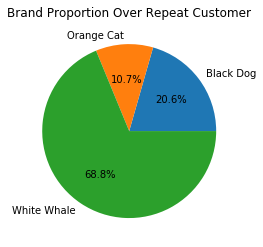

```python
#pie chart of proportions
fraction = list(repeat_prop)
label = list(repeat_prop.index)
plt.pie(fraction, labels = label, autopct = '%1.1f%%')
plt.title('Brand Proportion Over Repeat Customer');
```

From this aggregation of repeat customers, it would seem that the White Whale brand is the most popular brand at nearly 70% of purchases from repeat customers, while the Orange Cat brand and Black Dog brand occupy the remaining 30%. However, it is uncertain if this could be driven by a particular buyer or by a particular time. For instance, although unlikely, White Whale could be a single enormous purchase done by a single individual or supplier which would greatly inflate its popularity.

### Unique Repeat Customers

```python
#number of repeats from dataset
repeat_df.groupby(['customer']).count()['brand'].describe()
```

```
count    3334.000000
mean        1.939412
std         0.756562
min         1.000000
25%         1.000000
50%         2.000000
75%         2.000000
max         7.000000
Name: brand, dtype: float64
```

It would seem that on average the usual number of repeats per customer is around 2, with the maximum of 7. Although it would seem that there are no outrageous outliers in terms of repeat buyers, it may still be useful to graph the brand popularity proportions of strictly unique buyers. Unique customer will be defined by a unique combination of customer ID and petfood brand; by this definition a single customer ID could registered more than once in the dataset, but still be considered unique so long as the customer purchased more than one brand. This can arguably be considered valid because the scope of this analysis is not to determine the profile of a customer at an individual level, but an aggregate level.

```python
#creating unique customer dataframe
unique_repeat_df = repeat_df[repeat_df.duplicated(subset = ['customer', 'brand'])]
unique_repeat_df.info()
```

```
<class 'pandas.core.frame.DataFrame'>
Int64Index: 3132 entries, 9 to 10642
Data columns (total 5 columns):
customer        3132 non-null object
date_shipped    3132 non-null object
product_id      3132 non-null object
brand           3132 non-null object
channel         3132 non-null object
dtypes: object(5)
memory usage: 146.8+ KB
```

The number of unique entries is around half the original amount.

```python
#unique repeat customer proportions
unique_repeat_counts = unique_repeat_df.groupby('brand').count()['customer']
unique_repeat_prop = unique_repeat_counts / unique_repeat_df.shape[0]
unique_repeat_prop
```

```
brand
Black Dog      0.201149
Orange Cat     0.110153
White Whale    0.688697
Name: customer, dtype: float64
```

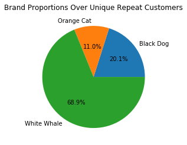

```python
#graph
plt.pie(list(unique_repeat_prop), labels = list(unique_repeat_prop.index), autopct = '%1.1f%%')
plt.title('Brand Proportions Over Unique Repeat Customers');
```

### Repeat Customers Graphed Over Time

One possible explanation for the large proportion of White Whale purchases, may be that White Whale purchases were simply purchased in large quantities at a certain point. Perhaps there was a fad that increased sales or that particular season neccessitated the purchase of a particular good at a particular brand(for instance, White Whale winter clothes).

```python
#time to graph dates over
time = mdates.drange(repeat_df.date_shipped.min(),
                      repeat_df.date_shipped.max() + datetime.timedelta(days = 1),
                      datetime.timedelta(days = 1))
```

```python
#creating data points over time per brand
black_dog_date = repeat_df.groupby(['brand', 'date_shipped'])['customer'].count()['Black Dog']
orange_cat_date = repeat_df.groupby(['brand', 'date_shipped'])['customer'].count()['Orange Cat']
white_whale_date = repeat_df.groupby(['brand', 'date_shipped'])['customer'].count()['White Whale']
```

```python
#filling missing date values
idx = pd.date_range(repeat_df.date_shipped.min(), repeat_df.date_shipped.max())
bd_date1 = black_dog_date.reindex(idx, fill_value = np.nan)
oc_date1 = orange_cat_date.reindex(idx, fill_value = np.nan)
ww_date1 = white_whale_date.reindex(idx, fill_value = np.nan);
```

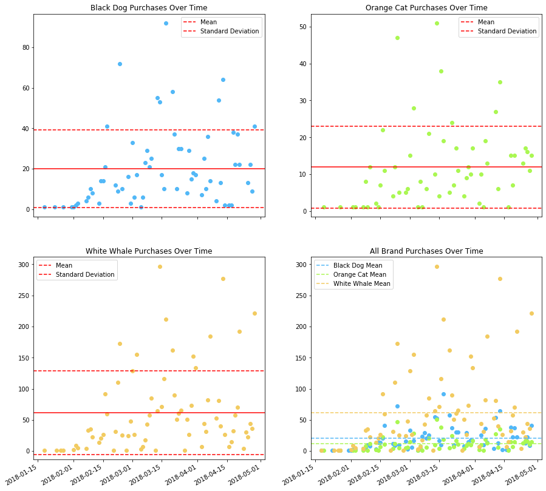

```python
f, ((ax1, ax2), (ax3, ax4)) = plt.subplots(2, 2, figsize=(15,15), sharex= True)

#Black Dog
ax1.plot_date(time, bd_date1, c ='#52b8f7')
ax1.set_title('Black Dog Purchases Over Time')
ax1.axhline(np.mean(bd_date1), color = 'r')
ax1.axhline(np.mean(bd_date1) + np.std(bd_date1), color = 'r', ls = '--', label = 'Mean')
ax1.axhline(np.mean(bd_date1) - np.std(bd_date1), color = 'r', ls = '--', label = 'Standard Deviation')
ax1.legend()

ax2.plot_date(time, oc_date1, c= '#aaf752')
ax2.set_title('Orange Cat Purchases Over Time')
ax2.axhline(np.mean(oc_date1), color = 'r')
ax2.axhline(np.mean(oc_date1) + np.std(oc_date1), color = 'r', ls = '--', label = 'Mean')
ax2.axhline(np.mean(oc_date1) - np.std(oc_date1), color = 'r', ls = '--', label = 'Standard Deviation')
ax2.legend()

ax3.plot_date(time, ww_date1, c='#f2cb61')
ax3.set_title('White Whale Purchases Over Time')
ax3.axhline(np.mean(ww_date1), color = 'r')
ax3.axhline(np.mean(ww_date1) + np.std(ww_date1), color = 'r', ls = '--', label = 'Mean')
ax3.axhline(np.mean(ww_date1) - np.std(ww_date1), color = 'r', ls = '--', label = 'Standard Deviation')
ax3.legend()

ax4.plot_date(time, bd_date1, c ='#52b8f7')
ax4.plot_date(time, oc_date1, c= '#aaf752')
ax4.plot_date(time, ww_date1, c='#f2cb61')
ax4.axhline(np.mean(bd_date1), color = '#52b8f7', ls = '--', label = 'Black Dog Mean')
ax4.axhline(np.mean(oc_date1), color = '#aaf752', ls = '--', label = 'Orange Cat Mean')
ax4.axhline(np.mean(ww_date1), color = '#f2cb61', ls = '--', label = 'White Whale Mean')
ax4.set_title('All Brand Purchases Over Time')
ax4.legend()

f.autofmt_xdate()
plt.show();
```

From these graphs, it is apparent that there is a fairly large degree of variation in the purchase amounts per day, which suggests the existence a few outliers; days with particularly high sales ("surges"), skew the data of the graph upwards. This phenomenon, regardless of brand, seems to be fairly similar across the board. For instance, a simple count of the number of days above and below the mean demonstrates a gross imbalance; given that a perfectly stable brand would have an relatively even number of sales that were both below and above the mean.

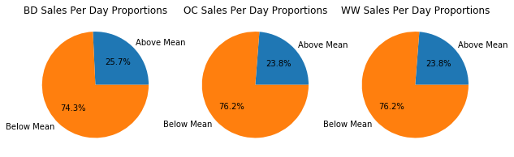

```python
#creating subplot grid
f, (ax1, ax2, ax3) = plt.subplots(1,3,figsize=(10,10))
#plotting
total = bd_date1.shape[0]
num_above = list(bd_date1 > bd_date1.mean()).count(True)
sizes = [num_above/total, (bd_date1.shape[0] - num_above)/total]
sizes
ax1.pie(sizes, labels = ['Above Mean', 'Below Mean'], autopct = '%1.1f%%')
ax1.set_title('BD Sales Per Day Proportions')

total = oc_date1.shape[0]
num_above = list(oc_date1 > oc_date1.mean()).count(True)
sizes = [num_above/total, (oc_date1.shape[0] - num_above)/total]
sizes
ax2.pie(sizes, labels = ['Above Mean', 'Below Mean'], autopct = '%1.1f%%')
ax2.set_title('OC Sales Per Day Proportions')

total = ww_date1.shape[0]
num_above = list(ww_date1 > ww_date1.mean()).count(True)
sizes = [num_above/total, (ww_date1.shape[0] - num_above)/total]
sizes
ax3.pie(sizes, labels = ['Above Mean', 'Below Mean'], autopct = '%1.1f%%')
ax3.set_title('WW Sales Per Day Proportions')

plt.show();
```

Here it can be observed in all brands that roughly three quarters of the sales per day distribution lies below the mean.

```python
print('The Black dog Skew {}. The Orange Cat skew is {}. The White Whale skew is is {}.'.format((scipy.stats.skew(bd_date1, nan_policy = 'omit')),(scipy.stats.skew(oc_date1, nan_policy = 'omit')), (scipy.stats.skew(ww_date1, nan_policy = 'omit'))                                                     ))
```

```
The Black dog Skew 1.4840155591020452. The Orange Cat skew is 1.6099113091148456. The White Whale skew is is 1.607756375601274.
```

The existance of surge days of relatively similar scale are also confirmed by the exceedingly similar amount of skewness between each brand. Skew greater than zero suggests weight in the right tail, meaning there are number of observerations that are inflating the mean amount of sales per day. It can be concluded, due to similar skew, that all brands experience surges, and at about the same amount relative to the mean sales per day.

However, as noted by the graph above, although the variation and skewness of each brand is similar, the *scale* is not. This is most apparent in the fourth graph, where each Brands mean is graphed against each other. By far, White Whale has a much higher mean sales per day than either of the other brands. Previously it was supposed that the White Whale sales was grossly inflated by a particular point in time. Yet, it is visibile that *all* brands experience some form of inflation, but, due to the similar degree of inflation, can still be compared. Since this is the case, White Whale's mean can be seen as more legitimate and further solidifies its posistion as the preferred brand amongst repeat customers.

### Conclusion:

It would seem that the White Whale Brand is the most popular brand amongst repeat customers both across the customer base and intertemporally. When testing the idea that a small subset of repeat customers may be pushing a large number of White Whale orders, thus inflating sales, the proportion of the White Whale Brand customers remained unchanged even after filtering only for unique repeat customers. When testing the idea that a surge purchase of White Whale orders at one point in time had inflated the sales, it was found that such surges do exist, but across all brands. **Overall, White Whale seems to be the preferred brand of a repeat customer.**

## Does the marketing channel used to acquire customers make a difference?

- Marketing causes brand bias? (continued exploration of previous question)
- Which channel results in more sales?
  - By brand
    - By product

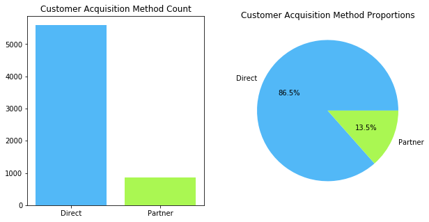

```python
#creating subplot grid
f, (ax1, ax2) = plt.subplots(1, 2, figsize=(10,5))
#plotting
total = repeat_df.shape[0]
count = repeat_df.groupby('channel').count()['customer']
prop = count / total
ax2.pie(prop, labels = prop.index, autopct = '%1.1f%%', colors = ['#52b8f7', '#aaf752'])
ax2.set_title('Customer Acquisition Method Proportions');

ax1.bar(count.index, count, color = ['#52b8f7', '#aaf752'])
ax1.set_title('Customer Acquisition Method Count')
plt.show()
```

```python
print('The count for customer acquistion for the entire sample are ', count[0], 'for the Direct channel and ', count[1], 'for the partner channel.')
```

```
The count for customer acquistion for the entire sample are  5595 for the Direct channel and  871 for the partner channel.
```

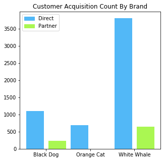

```python
count = repeat_df.groupby(['brand', 'channel']).count()['customer']
plt.figure(figsize = (5, 5))
plt.bar([0, 1, 2, 4, 5], count, color = ['#52b8f7', '#aaf752', '#52b8f7', '#52b8f7', '#aaf752'])
plt.title('Customer Acquisition Count By Brand')
plt.xticks([0.5, 2.5, 4.5], ('Black Dog', 'Orange Cat', 'White Whale'))

d_patch = mpatches.Patch(color='#52b8f7', label='Direct')
p_patch = mpatches.Patch(color='#aaf752', label='Partner')
plt.legend(handles=[d_patch, p_patch]);
```

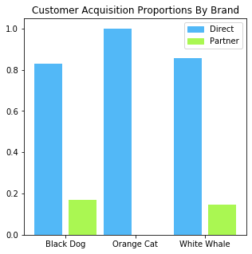

```python
prop = repeat_df.groupby(['brand', 'channel']).count()['customer'] / repeat_df.groupby(['brand']).count()['customer']
plt.figure(figsize = (5, 5))
plt.bar([0, 1, 2, 4, 5], prop, color = ['#52b8f7', '#aaf752', '#52b8f7', '#52b8f7', '#aaf752'])
plt.title('Customer Acquisition Proportions By Brand')
plt.xticks([0.5, 2.5, 4.5], ('Black Dog', 'Orange Cat', 'White Whale'))

d_patch = mpatches.Patch(color='#52b8f7', label='Direct')
p_patch = mpatches.Patch(color='#aaf752', label='Partner')
plt.legend(handles=[d_patch, p_patch]);
```

```python
print('Black Dog Direct Count: ', count[0], '| Black Dog Direct Proportion', prop[0])
print('Orange Cat Direct Count: ', count[2], '| Orange Cat Direct Proportion', prop[2])
print('White Whale Direct Count: ', count[3], '| White Whale Direct Proportion', prop[3])
```

```
Black Dog Direct Count:  1104 | Black Dog Direct Proportion 0.8300751879699249
Orange Cat Direct Count:  689 | Orange Cat Direct Proportion 1.0
White Whale Direct Count:  3802 | White Whale Direct Proportion 0.8549583989206206
```

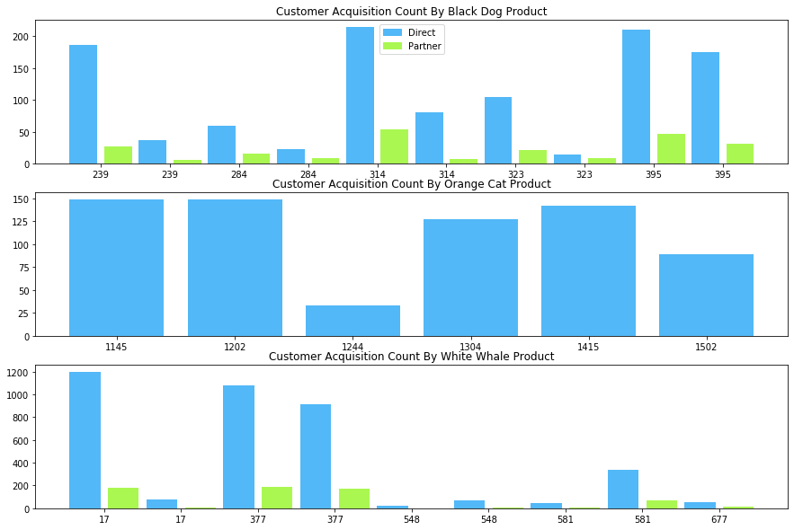

```python
bd_prod = repeat_df.groupby(['brand', 'product_id', 'channel']).count()['customer']['Black Dog']
oc_prod = repeat_df.groupby(['brand', 'product_id', 'channel']).count()['customer']['Orange Cat']
ww_prod = repeat_df.groupby(['brand', 'product_id', 'channel']).count()['customer']['White Whale']

f, (ax1, ax2, ax3) = plt.subplots(3, 1, figsize = (15, 10))

#black dog
ax1.bar(range(len(bd_prod.index)), bd_prod, color = ['#52b8f7', '#aaf752'] * len(bd_prod.index))
l = np.arange(len(bd_prod.index))
loc = [x+.5 for x in l if x % 2 ==0]
ax1.set_xticks(loc)
labels = [x[0] for x in bd_prod.index]
ax1.set_xticklabels(labels)
ax1.set_title('Customer Acquisition Count By Black Dog Product')

#legend
d_patch = mpatches.Patch(color='#52b8f7', label='Direct')
p_patch = mpatches.Patch(color='#aaf752', label='Partner')
ax1.legend(handles=[d_patch, p_patch])

#orange cat
ax2.bar(range(len(oc_prod.index)), oc_prod, color = ['#52b8f7'] * len(oc_prod.index))
l = np.arange(len(oc_prod.index))
ax2.set_xticks(np.arange(len(oc_prod.index)))
labels = [x[0] for x in oc_prod.index]
ax2.set_xticklabels(labels)
ax2.set_title('Customer Acquisition Count By Orange Cat Product')

#white whale
ax3.bar(range(len(ww_prod.index)), ww_prod, color = ['#52b8f7', '#aaf752'] * len(ww_prod.index))
l = np.arange(len(ww_prod.index))
loc = [x+.5 for x in l if x % 2 ==0]
ax3.set_xticks(loc)
labels = [x[0] for x in ww_prod.index]
ax3.set_xticklabels(labels)
ax3.set_title('Customer Acquisition Count By White Whale Product')

plt.show()
```

Finally, in the case that a specific product had to be targeted for sale within a brand, this sample demonstrates that a Direct Channel is still the most observed method of customer acquisition amongst repeat customers. **No matter the product or brand, customers who ordered a product were overwhelmingly acquired through a Direct Channel.**

## Conclusion

As stated before, the most effective method of customer acquistion amongst repeat customers is through a Direct Channel. Whether it be in a less popular brand such as Black Dog or Orange Cat, or within a more popular brand such as White Whale, repeat customers who ordered goods were ultimately acquired through a Direct channel. No specific brand or product was observed to have a majority of customers acquired through a partner channel, and, in the case of the Orange Cat brand, customers were exclusively acquired through the Direct Channel.

## Are there specific products which are associated with repeat purchases?

- Highlight top of each brand

```python
#amongst the repeat customer subset
#get count by brand
bd_pcount = repeat_df.groupby(['brand', 'product_id']).count()['customer']['Black Dog']
bd_pcount.sort_values(ascending = False, inplace = True)
oc_pcount = repeat_df.groupby(['brand', 'product_id']).count()['customer']['Orange Cat']
oc_pcount.sort_values(ascending = False, inplace = True)
ww_pcount = repeat_df.groupby(['brand', 'product_id']).count()['customer']['White Whale']
ww_pcount.sort_values(ascending = False, inplace = True)
#get proportions
bd_pprop = bd_pcount / repeat_df.groupby(['brand']).count()['customer']['Black Dog']
oc_pprop = oc_pcount / repeat_df.groupby(['brand']).count()['customer']['Orange Cat']
ww_pprop = ww_pcount / repeat_df.groupby(['brand']).count()['customer']['White Whale']

#get total count
total_pcount = pd.concat([bd_pcount, oc_pcount, ww_pcount])
```

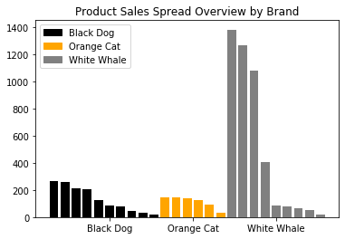

```python
plt.bar(np.arange(len(total_pcount)), total_pcount, color = ['black']*len(bd_pcount) + ['orange']*len(oc_pcount ) + ['grey']*len(ww_pcount))
plt.title('Product Sales Spread Overview by Brand')
plt.xticks([5, 12.5, 20], ['Black Dog', 'Orange Cat', 'White Whale'])
b_patch = mpatches.Patch(color='black', label='Black Dog')
o_patch = mpatches.Patch(color='orange', label='Orange Cat')
w_patch = mpatches.Patch(color = 'grey', label = 'White Whale')
plt.legend(handles=[b_patch, o_patch, w_patch])
plt.show()
```

By graphing each brand by product it is still very apparent that the White Whale brand sells exceptionally well against repeat customers. However, unlike the conclusion from before, it does not seem that the White Whale Brand is holistically a better brand than it's sister brands. Rather, in White Whale's case, the majority of the sales seem to consist of 4 specific products. Beyond that, the rest of the products actually underperform a good portion of the products from the other brands. Meanwhile, neither the Black Dog or the Orange Cat brands display such a large dropoff in sales, with the Black Dog brand having a relatively modest dropoff and the Orange Cat brand having a relatively stable sale throughout the dataset despite no particularly strong product.

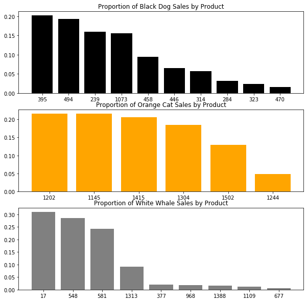

```python
f, (ax1, ax2, ax3) = plt.subplots(3, 1, figsize = (10, 10))

ax1.bar(np.arange(len(bd_pprop)), bd_pprop, color = 'black')
ax1.set_title('Proportion of Black Dog Sales by Product')
ax1.set_xticks(np.arange(len(bd_pprop)))
ax1.set_xticklabels(bd_pprop.index)

ax2.bar(np.arange(len(oc_pprop)), oc_pprop, color = 'orange')
ax2.set_title('Proportion of Orange Cat Sales by Product')
ax2.set_xticks(np.arange(len(oc_pprop)))
ax2.set_xticklabels(oc_pprop.index)

ax3.bar(np.arange(len(ww_pprop)), ww_pprop, color = 'grey')
ax3.set_title('Proportion of White Whale Sales by Product')
ax3.set_xticks(np.arange(len(ww_pprop)))
ax3.set_xticklabels(ww_pprop.index)

plt.show()
```

```python
#top 4
print('The proportion of all brand sales by the top 4 products of Black Dog is: ', bd_pprop[:4].sum())
print('The proportion of all brand sales by the top 4 products of Orange Cat is: ', oc_pprop[:4].sum())
print('The proportion of all brand sales by the top 4 products of White Whale is: ', ww_pprop[:4].sum())
```

```
The proportion of all brand sales by the top 4 products of Black Dog is:  0.7105263157894737
The proportion of all brand sales by the top 4 products of Orange Cat is:  0.8229317851959361
The proportion of all brand sales by the top 4 products of White Whale is:  0.9320890487969417
```

```python
print('The mean contribution from the remaining products of Black Dog is: ', bd_pprop[4:].mean())
print('The mean contribution from the remaining products of Orange Cat is: ', oc_pprop[4:].mean())
print('The mean contribution from the remaining products of White Whale is: ', ww_pprop[4:].mean())
```

```
The mean contribution from the remaining products of Black Dog is:  0.04824561403508771
The mean contribution from the remaining products of Orange Cat is:  0.08853410740203194
The mean contribution from the remaining products of White Whale is:  0.01358219024061165
```

When graphed by proportion alone, the disparity between White Whale's top products becomes even more apparent. In all, the top 4 brands, as stated above, consist of roughly 93% of all the sales within this sample; with the top 3 products commanding more than 70% of the sales. In drastic comparison, all products below that contribute to the remaining 1% on average.

A similar phenomonon is also visibile in the Black Dog brand sales, but not nearly as steep, as the top 4 only command the first 70%. However, unlike the rather even spread of the Orange Cat brand, the remaining 30% of the Black Dog brand is split amongst 6 additional products, making the average contribution per product only around 5%.

Lastly, the Orange Cat brand demonstrates a relatively even spread accross its product. Its top 4 constitute roughly 20% each of the total sales, with the last two product making a less even split of the last 20%.

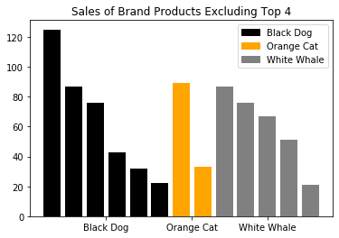

```python
remain = pd.concat([bd_pcount[4:], oc_pcount[4:], ww_pcount[4:]])
plt.bar(np.arange(len(remain)), remain, color = ['black']*len(bd_pcount[4:]) + ['orange']*len(oc_pcount[4:]) + ['grey']*len(ww_pcount[4:]))
plt.title('Sales of Brand Products Excluding Top 4')
plt.xticks([2.5, 6.5, 10], ['Black Dog', 'Orange Cat', 'White Whale'])
b_patch = mpatches.Patch(color='black', label='Black Dog')
o_patch = mpatches.Patch(color='orange', label='Orange Cat')
w_patch = mpatches.Patch(color = 'grey', label = 'White Whale')
plt.legend(handles=[b_patch, o_patch, w_patch])
plt.show()
```

## Conclusion

Looking at each brand through the perspective of individual product sales greatly expanded the insight gained from the previous analysis of repeat customer preferred brand. The particular preference towards White Whale was not actually attributed to the brand as a whole, but rather to roughly 4 products (17, 548, 581, and 1313) that made up the *vast* majority of the brands sales. A similar phenomenon was observed in the Black Dog brand, with a few specific products making up the majority of the brand sales, but not as extreme. When these top performers are excluded, the remaining products have a remarkbly similar performance accross the brands, although Black Dog still demonstrates a noticeable dropoff. However, such a graph is more related to topic of which products are *unwanted* by repeat customers rather than preferred.

In terms of top preferred products, not all brands demonstrate an absolute disparity like the White Whale brand and a minimum cutoff point would have to be artificially set. In this case study, a 15% portion of all brand sales will be the arbitrarily set minimum cuttoff for product preference based on a visual approximation of each brand.

**In this sample of repeat customers, given a product commands at least 15% of its respective brand sales, the top performing products per brand are as follows:**

- **Black Dog Products:** 395, 494, 239, and 1073
- **Orange Cat Products:** 1202, 1145, 1415, and 1304
- **White Whale Products:** 17, 548, and 581

# Which Top Products are still growing?

Given that top products were identified amongst repeat customers it is important to verify if each product's success was transient or intertemporal.

### Black Dog Top Products

```python
#products by date
bd_395 = repeat_df.groupby(['brand', 'product_id', 'date_shipped']).count()['customer']['Black Dog'][395]
bd_494 = repeat_df.groupby(['brand', 'product_id', 'date_shipped']).count()['customer']['Black Dog'][494]
bd_239 = repeat_df.groupby(['brand', 'product_id', 'date_shipped']).count()['customer']['Black Dog'][239]
bd_1073 = repeat_df.groupby(['brand', 'product_id', 'date_shipped']).count()['customer']['Black Dog'][1073]

#fill date values
idx = pd.date_range(repeat_df.date_shipped.min(), repeat_df.date_shipped.max())
bd_395 = bd_395.reindex(idx, fill_value = 0)
bd_494 = bd_494.reindex(idx, fill_value = 0)
bd_239 = bd_239.reindex(idx, fill_value = 0)
bd_1073 = bd_1073.reindex(idx, fill_value = 0)
```

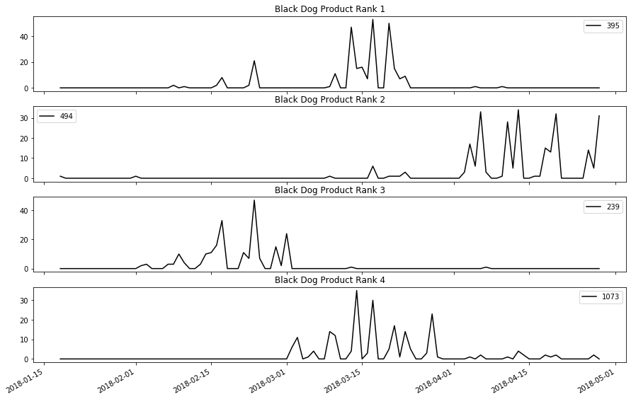

```python
f, (ax1, ax2, ax3, ax4) = plt.subplots(4, 1, figsize = (15, 10), sharex = True)

ax1.plot_date(time, bd_395, ls = '-', marker = 'None', label = '395', color = 'black')
ax1.set_title('Black Dog Product Rank 1')
ax1.legend()

ax2.plot_date(time, bd_494, ls = '-', marker = 'None', label = '494', color = 'black')
ax2.set_title('Black Dog Product Rank 2')
ax2.legend()

ax3.plot_date(time, bd_239, ls = '-', marker = 'None', label = '239', color = 'black')
ax3.set_title('Black Dog Product Rank 3')
ax3.legend()

ax4.plot_date(time, bd_1073, ls = '-', marker = 'None', label = '1073', color = 'black')
ax4.set_title('Black Dog Product Rank 4')
ax4.legend()

f.autofmt_xdate()
plt.show()
```

Graphing by time shows that not all products are doing uniformly well, and that certain products that were once top performers at a certain time have recently been completely stagnant; this is apparent in Black Dog product 239 and 395. Product 1073 now demonstrate much more modest sales, while product 494 is in a season of explosive success. **From this sample in time, it would seem worthwhile to invest heavily in product 494, modestly in 1073, and less in 395 and 239.**

### Orange Cat Top Products

```python
#products by date
oc_1202 = repeat_df.groupby(['brand', 'product_id', 'date_shipped']).count()['customer']['Orange Cat'][1202]
oc_1145 = repeat_df.groupby(['brand', 'product_id', 'date_shipped']).count()['customer']['Orange Cat'][1145]
oc_1415 = repeat_df.groupby(['brand', 'product_id', 'date_shipped']).count()['customer']['Orange Cat'][1415]
oc_1304 = repeat_df.groupby(['brand', 'product_id', 'date_shipped']).count()['customer']['Orange Cat'][1304]

#fill date values
idx = pd.date_range(repeat_df.date_shipped.min(), repeat_df.date_shipped.max())
oc_1202 = oc_1202.reindex(idx, fill_value = 0)
oc_1145 = oc_1145.reindex(idx, fill_value = 0)
oc_1415 = oc_1415.reindex(idx, fill_value = 0)
oc_1304 = oc_1304.reindex(idx, fill_value = 0)
```

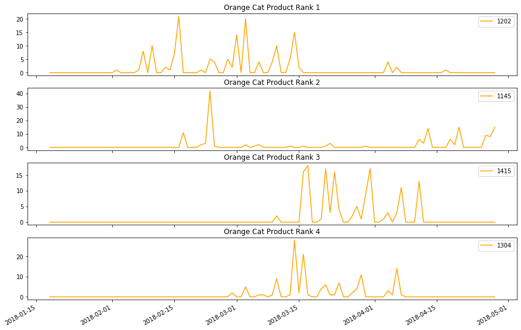

```python
f, (ax1, ax2, ax3, ax4) = plt.subplots(4, 1, figsize = (15, 10), sharex = True)

ax1.plot_date(time, oc_1202, ls = '-', marker = 'None', label = '1202', color = 'orange')
ax1.set_title('Orange Cat Product Rank 1')
ax1.legend()

ax2.plot_date(time, oc_1145, ls = '-', marker = 'None', label = '1145', color = 'orange')
ax2.set_title('Orange Cat Product Rank 2')
ax2.legend()

ax3.plot_date(time, oc_1415, ls = '-', marker = 'None', label = '1415', color = 'orange')
ax3.set_title('Orange Cat Product Rank 3')
ax3.legend()

ax4.plot_date(time, oc_1304, ls = '-', marker = 'None', label = '1304', color = 'orange')
ax4.set_title('Orange Cat Product Rank 4')
ax4.legend()

f.autofmt_xdate()
plt.show()
```

Unfortunately, the Orange Cat brand does not demonstrate very good recent sales in any of its products, save for product 1145. Although in the past the Orange Cat brand enjoyed a fair bit of success during Feburay to April, in recent weeks it has largely fallen off. **In all, only product 1145 in recent weeks teases a modest investment, and as a whole the Orange Cat brand should be considered a low priority.**

### White Whale Top Products

```python
#products by date 17, 548, 581
ww_17 = repeat_df.groupby(['brand', 'product_id', 'date_shipped']).count()['customer']['White Whale'][17]
ww_548 = repeat_df.groupby(['brand', 'product_id', 'date_shipped']).count()['customer']['White Whale'][548]
ww_581 = repeat_df.groupby(['brand', 'product_id', 'date_shipped']).count()['customer']['White Whale'][581]

#fill date values
idx = pd.date_range(repeat_df.date_shipped.min(), repeat_df.date_shipped.max())
ww_17 = ww_17.reindex(idx, fill_value = 0)
ww_548 = ww_548.reindex(idx, fill_value = 0)
ww_581 = ww_581.reindex(idx, fill_value = 0)
```

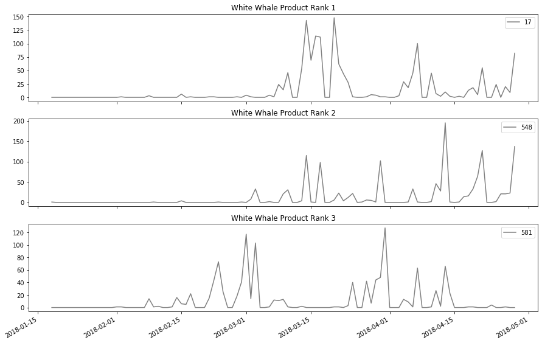

```python
f, (ax1, ax2, ax3) = plt.subplots(3, 1, figsize = (15, 10), sharex = True)

ax1.plot_date(time, ww_17, ls = '-', marker = 'None', label = '17', color = 'grey')
ax1.set_title('White Whale Product Rank 1')
ax1.legend()

ax2.plot_date(time, ww_548, ls = '-', marker = 'None', label = '548', color = 'grey')
ax2.set_title('White Whale Product Rank 2')
ax2.legend()

ax3.plot_date(time, ww_581, ls = '-', marker = 'None', label = '581', color = 'grey')
ax3.set_title('White Whale Product Rank 3')
ax3.legend()

f.autofmt_xdate()
plt.show()
```

As somewhat expected by the leading brand, the White Whale's top 3 products have shown impressive results. However, it would seem that product 581 has stagnated while the top two products 17 and 548 continue to show outstanding growth; in particular, 584 seems to project numbers that suggest it will soon eclipse product 17 in rank. **In all it would be worthwhile to invest heavily in products 17 and 584 while tapering off product 581. However, cutting the product completely could be detrimental since the brand and product has a proven record of success.**

# Reccomendations

In all, this sample and subsequent analysis have shown that among repeat customers the White Whale brand is by far the most successful. However, this success is due to a select few products which have grossly inflated the brand's presence in the sample, while the rest of products within the brand have had a mediocre performance. Moreover, within the White Whale brand, the top two products show a continued projection for success while the third ranked product seems to have stagnated. As a whole, the White Whale brand is likely carried by its top products, and though it would be beneficial to invest heavily in the brand, it would hasty to invest exclusively.

Amongst the next two brands, the Black Dog brand shows much more promise than the Orange Cat brand. Not only has it had more success overall, but its products have shown more recent success that the Orange Cat brand simply has not contested. The Black Dog brand, however, contains the most products out of all the brands, and as a whole demonstrates very tapered sales; most likely, this brand could use more specific reworking of its products, trimming those that have obviously underperformed.

In total a broad overview of reccomendations from this analysis are as follows:

- Invest heavily in the White Whale brand, particularily in the top 2 products, and reconsider the products outside the top 4.
- Invest modestly in the Black Dog brand, particularly in the 2nd ranked product, and consider trimming the brand of underperforming products.
- Invest minimally in the Orange Cat brand.
- Invest heavily in direct channels of customer acquisition (covered in respective section).

# Conclusion

As a whole the profile of a repeat customer seems to be heavily inclined towards the top products of the White Whale Brand with the strong majority of being acquired through a Direct Channel.

## Caveat

Even though these are the reccomendations from this analysis, there are still a number of factors that are simply not avaliable in the dataset. Valuable information such as region, product type, customer satisfaction, amongst others, could provide many other insights. For instance, although the Orange Cat Brand does quite poorly in these overall sales, it could be the favorite of a region and removing the brand entirely could resulting in losing the company's presence in that region.

Also, as briefly noted above, these reccomendations are *broad* insights from the dataset, as the scope of this analysis was limited to profiling the preferences of a repeat customer. Any major product decisions likely neccessitate a brand specific investigation/analysis.